# Stanford Psychology Climate Survey: 2018-2019

Lucy King

# Goal

The goal of the Psychology Department Climate Survey is provide the department with insights into feelings of inclusion and equality (or lack thereof) within the graduate student, postdoc, and research staff population. This information will inform efforts to cultivate an inclusive community that values diverse questions, viewpoints, approaches, and participant samples to foster ingenuity, challenge biases, and promote intellectual growth. Further, this information will inform possible actions to foster individual and collective wellbeing, which is requisite for academic success.

# Method

In Summer 2019, graduate students, postdoctoral fellows, and research staff were emailed an online link to complete the Climate Survey (a PDF of the survey is available on the Psychology Graduate Students Google Drive in the “Climate Survey” folder).

The survey included questions about feelings of belonging uncertainty, stereotype threat (i.e., concerns about negative judgement due to identity), contextual threat (i.e., beliefs and experiences bias and discrimination), beliefs about collective action (i.e., beliefs that others value increasing inclusivity), and gender dynamics (i.e., concerns about issues surrounding gender identity and harassment). In addition, we collected information concerning participation in the Diversity Committee (i.e., past participation and interest). We asked minimal demographics questions to avoid identifiability within the relatively small sample, emphasizing that these questions were optional.

# Participants

```r
d0 %>%
  count(position) %>%
  mutate(
    proportion = n / sum(n)
  )
```

```
## # A tibble: 4 x 3
##   position                  n proportion
##   <chr>                 <int>      <dbl>
## 1 Graduate student         27      0.45
## 2 Postdoctoral fellow       7      0.117
## 3 Research staff member    11      0.183
## 4 <NA>                     15      0.25
```

```r
d0 %>%
  count(gender) %>%
  mutate(
    proportion = n / sum(n)
  )
```

```
## # A tibble: 3 x 3
##   gender     n proportion
##   <chr>  <int>      <dbl>
## 1 Female    30      0.5
## 2 Male      16      0.267
## 3 <NA>      14      0.233
```

```r
d0 %>%
  count(minority) %>%
  mutate(
    proportion = n / sum(n)
  )
```

```
## # A tibble: 3 x 3
##   minority     n proportion
##   <chr>    <int>      <dbl>
## 1 No          27       0.45
## 2 Yes         18       0.3
## 3 <NA>        15       0.25
```

We received 60 response to the survey. We included optional questions about position in the department (graduate student, postdoc, research staff), gender identity (female, male, other/non-binary), and identity as an underrepresented minority. Among participants who responded, the majority (N = 27) were graduate students, followed by research staff (N = 11), and postdoctoral fellows (N = 7). In terms of gender, approximately twice as many participants identified as female (N = 30) compared to male (N = 16); no one identified as “other/non-binary.” Finally, 18 participants identified as an underrepresented minority.

# Results

## Belonging uncertainty

```r
## overall
count_d_belong <-
  d0 %>%
  count(d_belong) %>%
  mutate(
    proportion = n / sum(n)
  ) %>%
  arrange(desc(n))

count_d_belong
```

```
## # A tibble: 5 x 3
##   d_belong        n proportion
##   <chr>       <int>      <dbl>
## 1 Sometimes      30     0.5
## 2 Hardly ever    17     0.283
## 3 Frequently     10     0.167
## 4 Never           2     0.0333
## 5 Always          1     0.0167
```

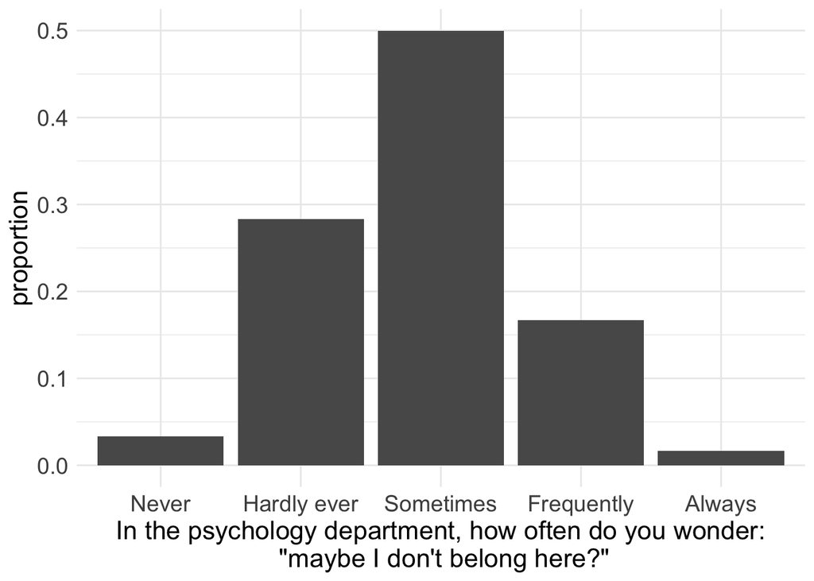

```r
count_d_belong %>%
  mutate(
    d_belong = factor(
      d_belong,
      levels = c("Never", "Hardly ever", "Sometimes", "Frequently", "Always")
    )
  ) %>%
  ggplot(aes(d_belong, proportion)) +
  geom_col() +
  hist_theme +
  labs(
    x = "In the psychology department, how often do you wonder:\n \"maybe I don't belong here?\""
  )
```

```r
## by minority status
count_d_belong_min <-
  d0 %>%
  count(minority_text, d_belong) %>%
  group_by(minority_text) %>%
  mutate(
    proportion = n / sum(n)
  ) %>%
  arrange(minority_text, desc(n))

count_d_belong_min
```

```
## # A tibble: 12 x 4
## # Groups:   minority_text [3]
##    minority_text d_belong        n proportion
##    <fct>         <chr>       <int>      <dbl>
##  1 Non-minority  Sometimes      12     0.444
##  2 Non-minority  Hardly ever     9     0.333
##  3 Non-minority  Frequently      4     0.148
##  4 Non-minority  Always          1     0.0370
##  5 Non-minority  Never           1     0.0370
##  6 Minority      Sometimes      10     0.556
##  7 Minority      Frequently      4     0.222
##  8 Minority      Hardly ever     3     0.167
##  9 Minority      Never           1     0.0556
## 10 No response   Sometimes       8     0.533
## 11 No response   Hardly ever     5     0.333
## 12 No response   Frequently      2     0.133
```

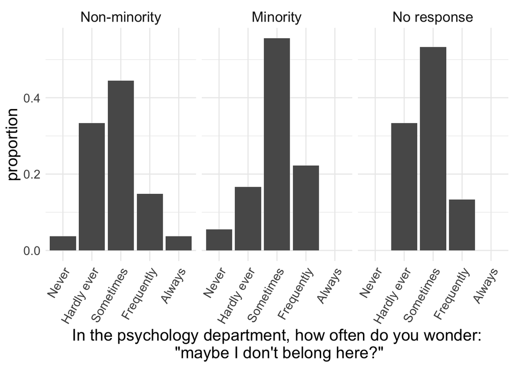

```r
count_d_belong_min %>%
  mutate(
    d_belong = factor(
      d_belong,
      levels = c("Never", "Hardly ever", "Sometimes", "Frequently", "Always")
    )
  ) %>%
  ggplot(aes(d_belong, proportion)) +
  geom_col() +
  hist_facet_theme +
  labs(
    x = "In the psychology department, how often do you wonder:\n \"maybe I don't belong here?\""
  ) +
  facet_grid(.~minority_text)
```

```r
# overall
count_a_belong <-
  d0 %>%
  count(a_belong) %>%
  mutate(
    proportion = n / sum(n)
  ) %>%
  arrange(desc(n))

count_a_belong
```

```
## # A tibble: 3 x 3
##   a_belong        n proportion
##   <chr>       <int>      <dbl>
## 1 Sometimes      30      0.5
## 2 Frequently     20      0.333
## 3 Hardly ever    10      0.167
```

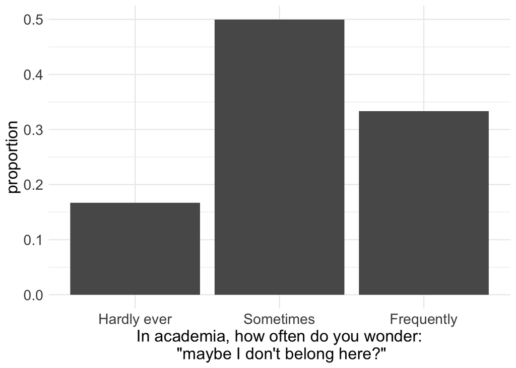

```r
count_a_belong %>%
  mutate(
    a_belong = factor(
      a_belong,
      levels = c("Never", "Hardly ever", "Sometimes", "Frequently", "Always")
    )
  ) %>%
  ggplot(aes(a_belong, proportion)) +
  geom_col() +
  theme_minimal() +
  hist_theme +
  labs(
    x = "In academia, how often do you wonder:\n \"maybe I don't belong here?\""
  )
```

```r
## by minority status
count_a_belong_min <-
  d0 %>%
  count(minority_text, a_belong) %>%
  group_by(minority_text) %>%
  mutate(
    proportion = n / sum(n)
  ) %>%
  arrange(minority_text, desc(n))

count_a_belong_min
```

```
## # A tibble: 9 x 4
## # Groups:   minority_text [3]
##   minority_text a_belong        n proportion
##   <fct>         <chr>       <int>      <dbl>
## 1 Non-minority  Sometimes      13      0.481
## 2 Non-minority  Frequently     11      0.407
## 3 Non-minority  Hardly ever     3      0.111
## 4 Minority      Sometimes       8      0.444
## 5 Minority      Frequently      6      0.333
## 6 Minority      Hardly ever     4      0.222
## 7 No response   Sometimes       9      0.6
## 8 No response   Frequently      3      0.2
## 9 No response   Hardly ever     3      0.2
```

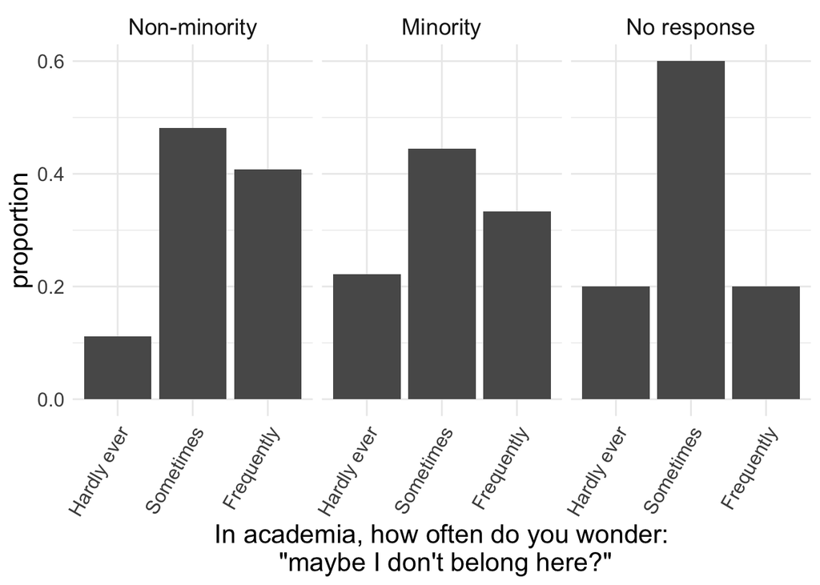

```r
count_a_belong_min %>%
  mutate(
    a_belong = factor(
      a_belong,
      levels = c("Never", "Hardly ever", "Sometimes", "Frequently", "Always")
    )
  ) %>%
  ggplot(aes(a_belong, proportion)) +
  geom_col() +
  hist_facet_theme +
  labs(
    x = "In academia, how often do you wonder:\n \"maybe I don't belong here?\""
  ) +
  facet_grid(.~minority_text)
```

When participants were asked about the frequency with which they wondered “maybe I don’t belong” in the Psychology Department and in academia generally, the modal response was “sometimes”. Indeed, fifty proportion of students endorsed “sometimes.”

When thinking about the Psychology Department, very few participants reported never feeling concerned about belonging (3%). Therefore, having at least some concerns about belonging is a typical experience in the department. When thinking about academia, no one reported “never” or “always” feeling concerned about belonging; one third of participants reported “frequently” feeling concerned.

## Stereotype threat

```r
# overall
count_judge_race <-
  d0 %>%
  count(judge_race) %>%
  mutate(
    proportion = n / sum(n)
  ) %>%
  arrange(desc(n))

count_judge_race
```

```
## # A tibble: 4 x 3
##   judge_race     n proportion
##   <chr>      <int>      <dbl>
## 1 Not at all    40     0.667
## 2 Somewhat      17     0.283
## 3 Moderately     2     0.0333
## 4 Extremely      1     0.0167
```

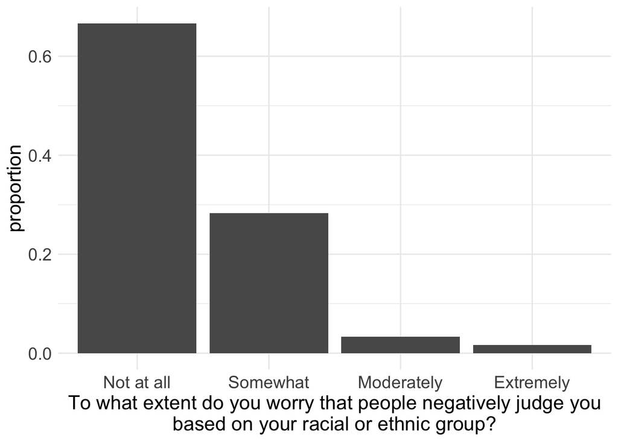

```r
count_judge_race %>%
  mutate(
    judge_race = factor(
      judge_race,
      levels = c("Not at all", "Somewhat", "Moderately", "A lot", "Extremely")
    )
  ) %>%
  ggplot(aes(judge_race, proportion)) +
  geom_col() +
  hist_theme +
  labs(
    x = "To what extent do you worry that people negatively judge you\nbased on your racial or ethnic group?"
  )
```

```r
# by minority status
count_judge_race_min <-
  d0 %>%
  count(minority_text, judge_race) %>%
  group_by(minority_text) %>%
  mutate(
    proportion = n / sum(n)
  ) %>%
  arrange(minority_text, desc(n))

count_judge_race_min
```

```
## # A tibble: 9 x 4
## # Groups:   minority_text [3]
##   minority_text judge_race     n proportion
##   <fct>         <chr>      <int>      <dbl>
## 1 Non-minority  Not at all    23     0.852
## 2 Non-minority  Somewhat       3     0.111
## 3 Non-minority  Moderately     1     0.0370
## 4 Minority      Somewhat       9     0.5
## 5 Minority      Not at all     8     0.444
## 6 Minority      Extremely      1     0.0556
## 7 No response   Not at all     9     0.6
## 8 No response   Somewhat       5     0.333
## 9 No response   Moderately     1     0.0667
```

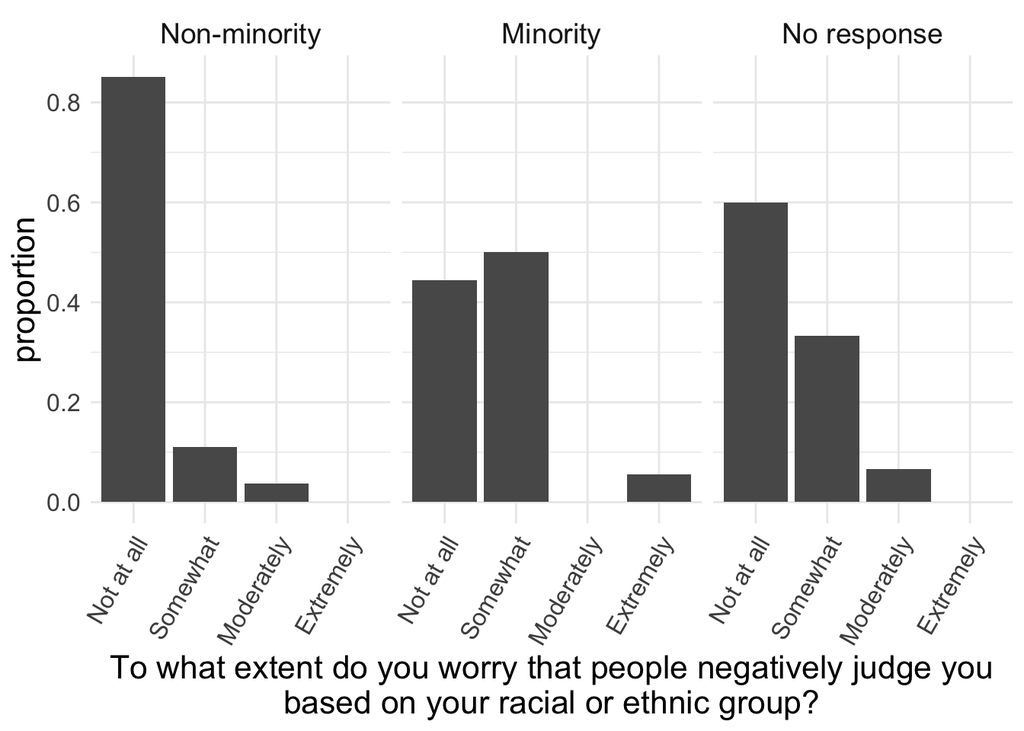

```r
count_judge_race_min %>%
  mutate(
    judge_race = factor(
      judge_race,
      levels = c("Not at all", "Somewhat", "Moderately", "A lot", "Extremely")
    )
  ) %>%
  ggplot(aes(judge_race, proportion)) +
  geom_col() +
  hist_facet_theme +
  labs(
    x = "To what extent do you worry that people negatively judge you\nbased on your racial or ethnic group?"
  ) +
  facet_grid(.~minority_text)
```

```r
# overall
count_judge_class <-
  d0 %>%
  count(judge_class) %>%
  mutate(
    proportion = n / sum(n)
  ) %>%
  arrange(desc(n))

count_judge_class
```

```
## # A tibble: 5 x 3
##   judge_class     n proportion
##   <chr>       <int>      <dbl>
## 1 Not at all     36     0.6
## 2 Somewhat       19     0.317
## 3 Moderately      3     0.05
## 4 A lot           1     0.0167
## 5 Extremely       1     0.0167
```

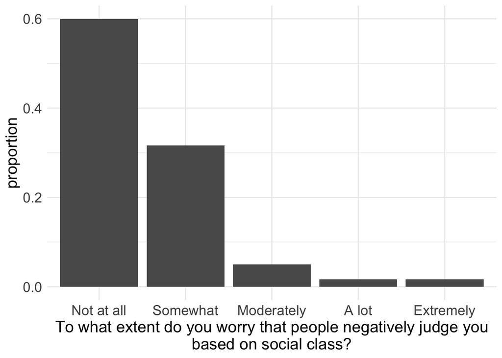

```r
count_judge_class %>%
  mutate(
    judge_class = factor(
      judge_class,
      levels = c("Not at all", "Somewhat", "Moderately", "A lot", "Extremely")
    )
  ) %>%
  ggplot(aes(judge_class, proportion)) +
  geom_col() +
  hist_theme +
  labs(
    x = "To what extent do you worry that people negatively judge you\nbased on social class?"
  )
```

```r
# overall
count_judge_gender <-
  d0 %>%
  count(judge_gender) %>%
  mutate(
    proportion = n / sum(n)
  ) %>%
  arrange(desc(n))

count_judge_gender
```

```
## # A tibble: 5 x 3
##   judge_gender     n proportion
##   <chr>        <int>      <dbl>
## 1 Not at all      34     0.567
## 2 Somewhat        19     0.317
## 3 A lot            3     0.05
## 4 Moderately       3     0.05
## 5 Extremely        1     0.0167
```

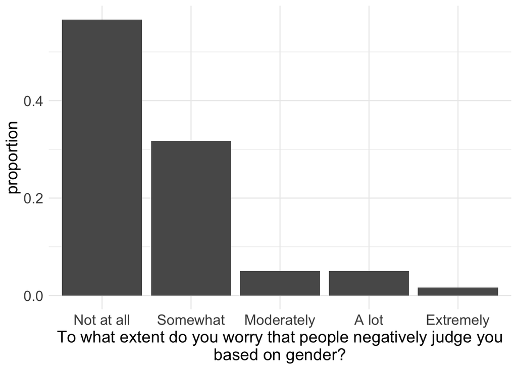

```r
count_judge_gender %>%
  mutate(
    judge_gender = factor(
      judge_gender,
      levels = c("Not at all", "Somewhat", "Moderately", "A lot", "Extremely")
    )
  ) %>%
  ggplot(aes(judge_gender, proportion)) +
  geom_col() +
  hist_theme +
  labs(
    x = "To what extent do you worry that people negatively judge you\nbased on gender?"
  )
```

```r
# by gender
count_judge_gender_gender <-
  d0 %>%
  count(gender_text, judge_gender) %>%
  group_by(gender_text) %>%
  mutate(
    proportion = n / sum(n)
  ) %>%
  arrange(gender_text, desc(n))

count_judge_gender_gender
```

```
## # A tibble: 10 x 4
## # Groups:   gender_text [3]
##    gender_text judge_gender     n proportion
##    <chr>       <chr>        <int>      <dbl>
##  1 Female      Not at all      12     0.4
##  2 Female      Somewhat        12     0.4
##  3 Female      A lot            3     0.1
##  4 Female      Moderately       2     0.0667
##  5 Female      Extremely        1     0.0333
##  6 Male        Not at all      11     0.688
##  7 Male        Somewhat         4     0.25
##  8 Male        Moderately       1     0.0625
##  9 No response Not at all      11     0.786
## 10 No response Somewhat         3     0.214
```

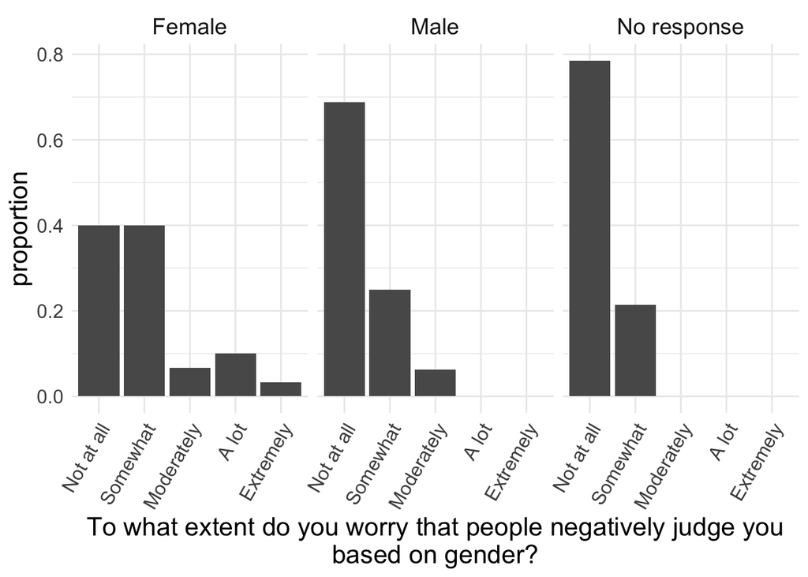

```r
count_judge_gender_gender %>%
  mutate(
    judge_gender = factor(
      judge_gender,
      levels = c("Not at all", "Somewhat", "Moderately", "A lot", "Extremely")
    )
  ) %>%
  ggplot(aes(judge_gender, proportion)) +
  geom_col() +
  hist_facet_theme +
  labs(
    x = "To what extent do you worry that people negatively judge you\nbased on gender?"
  ) +
  facet_grid(.~gender_text)
```

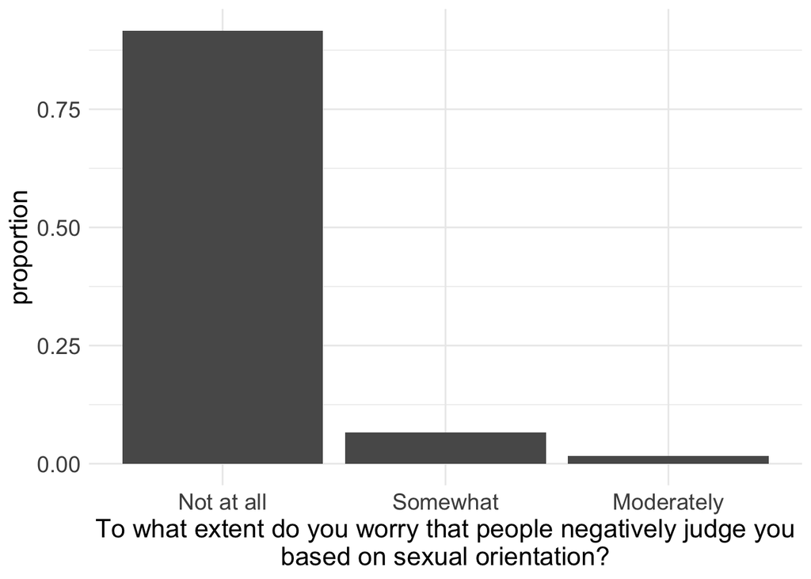

```r
count_judge_sexual <-
  d0 %>%
  count(judge_sexual) %>%
  mutate(
    proportion = n / sum(n)
  ) %>%
  arrange(desc(n))

count_judge_sexual %>%
  mutate(
    judge_sexual = factor(
      judge_sexual,
      levels = c("Not at all", "Somewhat", "Moderately", "A lot", "Extremely")
    )
  ) %>%
  ggplot(aes(judge_sexual, proportion)) +
  geom_col() +
  hist_theme +
  labs(
    x = "To what extent do you worry that people negatively judge you\nbased on sexual orientation?"
  )
```

```r
count_judge_health <-
  d0 %>%
  count(judge_health) %>%
  mutate(
    proportion = n / sum(n)
  ) %>%
  arrange(desc(n))

count_judge_health
```

```
## # A tibble: 4 x 3
##   judge_health     n proportion
##   <chr>        <int>      <dbl>
## 1 Not at all      29      0.483
## 2 Somewhat        19      0.317
## 3 A lot            6      0.1
## 4 Moderately       6      0.1
```

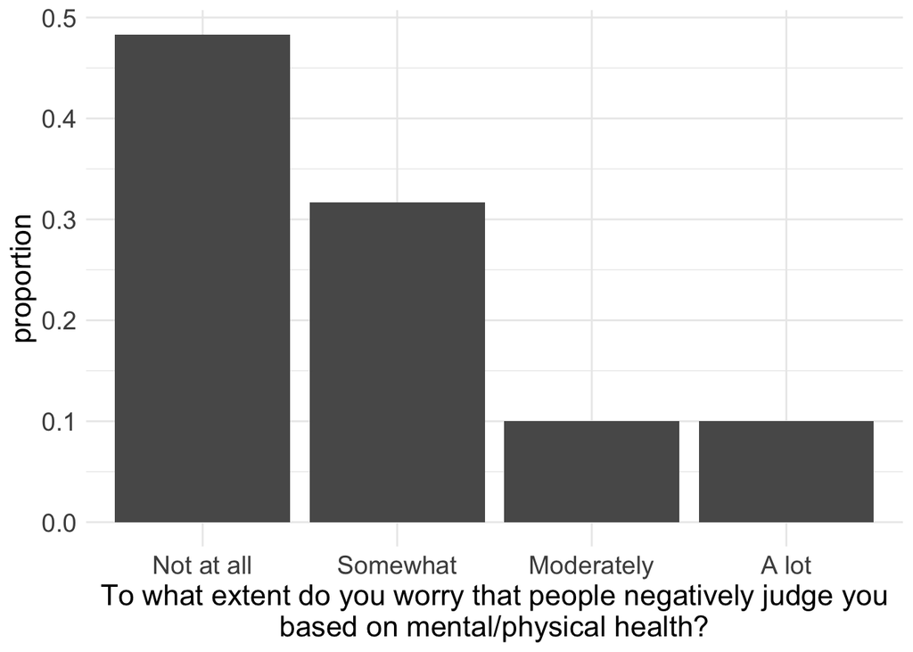

```r
count_judge_health %>%
  mutate(
    judge_health = factor(
      judge_health,
      levels = c("Not at all", "Somewhat", "Moderately", "A lot", "Extremely")
    )
  ) %>%
  ggplot(aes(judge_health, proportion)) +
  geom_col() +
  hist_theme +
  labs(
    x = "To what extent do you worry that people negatively judge you\nbased on mental/physical health?"
  )
```

## Contextual threat

```r
# overall
count_bias_belief <-
  d0 %>%
  count(bias_belief) %>%
  mutate(
    proportion = n / sum(n)
  ) %>%
  arrange(desc(n))

count_bias_belief
```

```
## # A tibble: 4 x 3
##   bias_belief     n proportion
##   <chr>       <int>      <dbl>
## 1 Somewhat       28      0.467
## 2 Moderately     14      0.233
## 3 Not at all     11      0.183
## 4 A lot           7      0.117
```

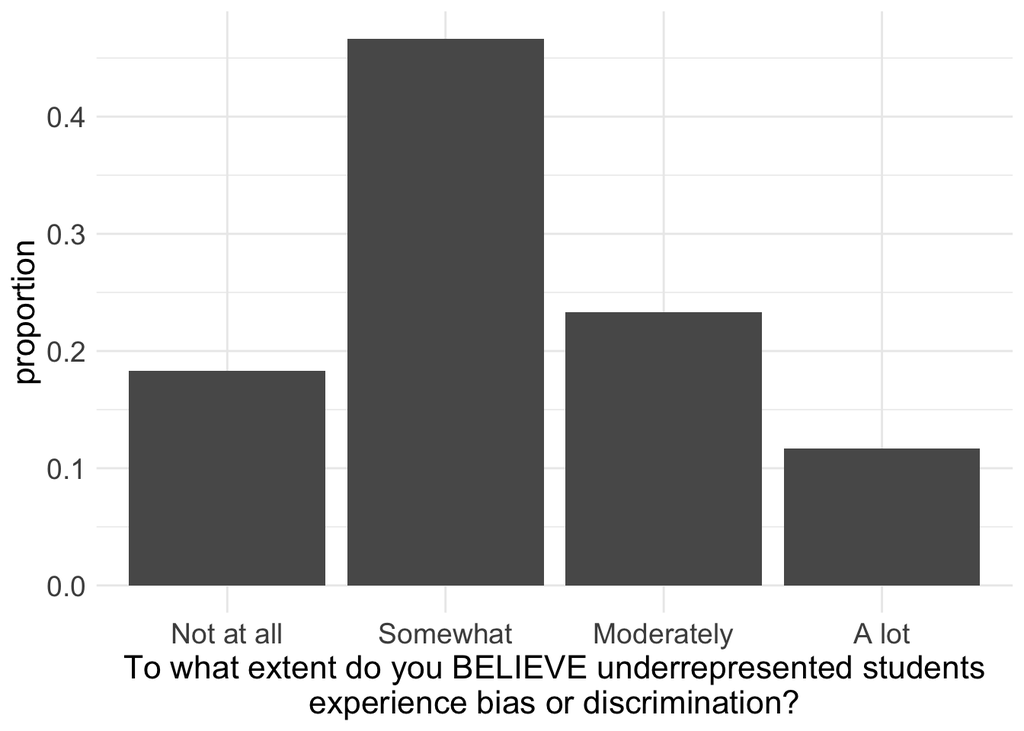

```r
count_bias_belief %>%
  mutate(
    bias_belief = factor(
      bias_belief,
      levels = c("Not at all", "Somewhat", "Moderately", "A lot", "Extremely")
    )
  ) %>%
  ggplot(aes(bias_belief, proportion)) +
  geom_col() +
  hist_theme +
  labs(
    x = "To what extent do you BELIEVE underrepresented students\nexperience bias or discrimination?"
  )
```

```r
# by minority status
count_bias_belief_min <-
  d0 %>%
  count(minority_text, bias_belief) %>%
  group_by(minority_text) %>%
  mutate(
    proportion = n / sum(n)
  ) %>%
  arrange(minority_text, desc(n))

count_bias_belief_min
```

```
## # A tibble: 12 x 4
## # Groups:   minority_text [3]
##    minority_text bias_belief     n proportion
##    <fct>         <chr>       <int>      <dbl>
##  1 Non-minority  Somewhat       13     0.481
##  2 Non-minority  Moderately      8     0.296
##  3 Non-minority  A lot           4     0.148
##  4 Non-minority  Not at all      2     0.0741
##  5 Minority      Somewhat        8     0.444
##  6 Minority      Moderately      4     0.222
##  7 Minority      Not at all      4     0.222
##  8 Minority      A lot           2     0.111
##  9 No response   Somewhat        7     0.467
## 10 No response   Not at all      5     0.333
## 11 No response   Moderately      2     0.133
## 12 No response   A lot           1     0.0667
```

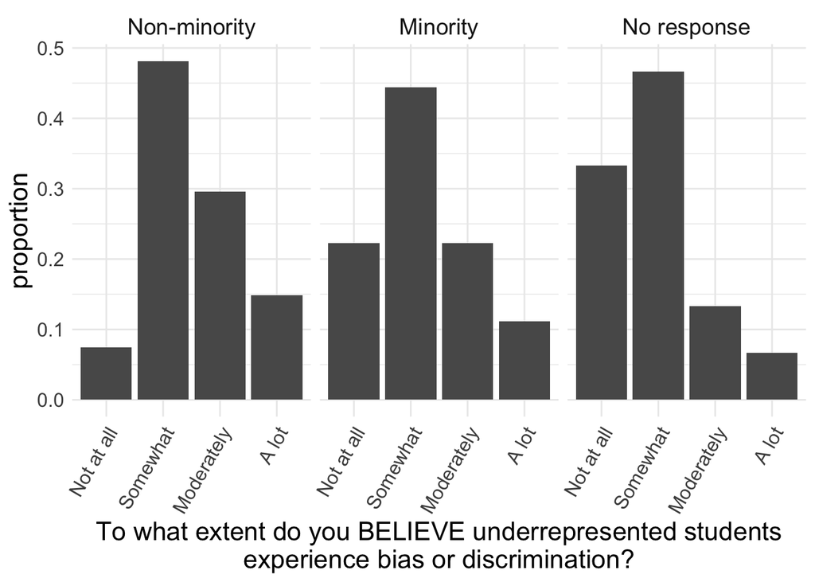

```r
count_bias_belief_min %>%
  mutate(
    bias_belief = factor(
      bias_belief,
      levels = c("Not at all", "Somewhat", "Moderately", "A lot", "Extremely")
    )
  ) %>%
  ggplot(aes(bias_belief, proportion)) +
  geom_col() +
  hist_facet_theme +
  labs(
    x = "To what extent do you BELIEVE underrepresented students\nexperience bias or discrimination?"
  ) +
  facet_grid(.~minority_text)
```

```r
count_bias_exp <-
  d0 %>%
  count(bias_exp) %>%
  mutate(
    proportion = n / sum(n)
  ) %>%
  arrange(desc(n))

count_bias_exp
```

```
## # A tibble: 4 x 3
##   bias_exp                   n proportion
##   <chr>                  <int>      <dbl>
## 1 Never                     28     0.467
## 2 Less than once a month    23     0.383
## 3 Every month                8     0.133
## 4 Every week                 1     0.0167
```

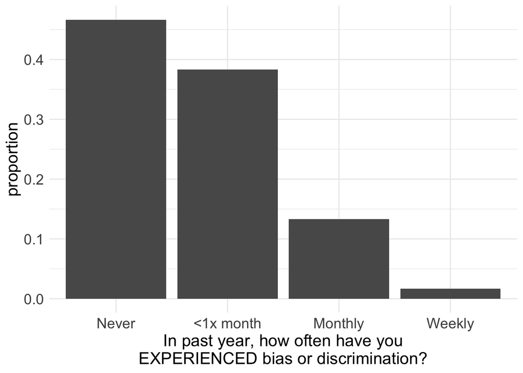

```r
count_bias_exp %>%
  mutate(
    bias_exp = factor(
      bias_exp,
      levels = c(
        "Never",
        "Less than once a month",
        "Every month",
        "Every week",
        "Every day"
      ),
      labels = c(
        "Never",
        "<1x month",
        "Monthly",
        "Weekly",
        "Daily"
      )
    )
  ) %>%
  ggplot(aes(bias_exp, proportion)) +
  geom_col() +
  hist_theme +
  labs(
    x = "In past year, how often have you\nEXPERIENCED bias or discrimination?"
  )
```

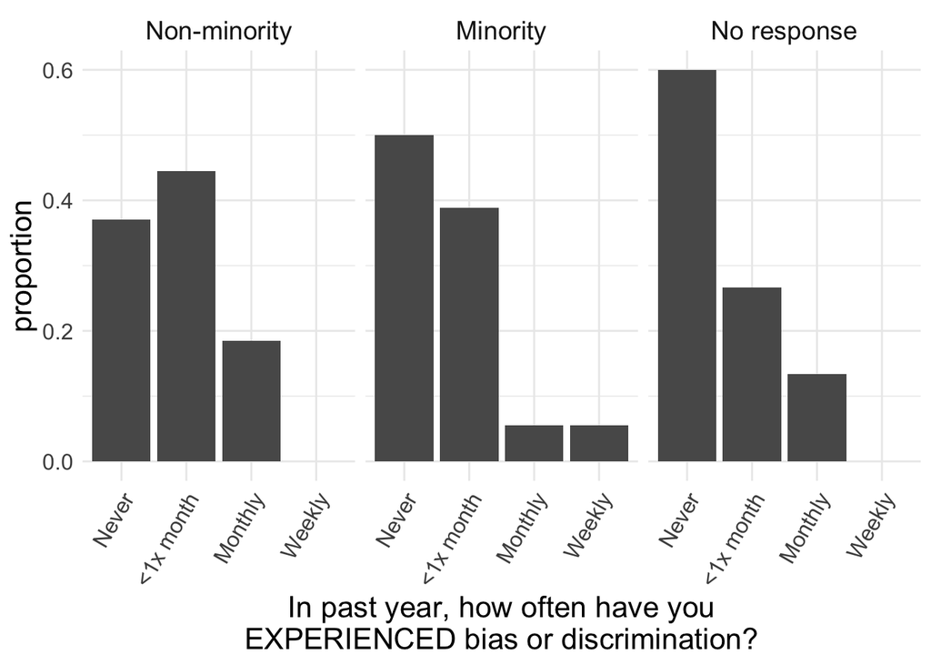

```r
count_bias_exp_min <-
  d0 %>%
  count(minority_text, bias_exp) %>%
  group_by(minority_text) %>%
  mutate(
    proportion = n / sum(n)
  ) %>%
  arrange(minority_text, desc(n))

count_bias_exp_min %>%
  mutate(
    bias_exp = factor(
      bias_exp,
      levels = c(
        "Never",
        "Less than once a month",
        "Every month",
        "Every week",
        "Every day"
      ),
      labels = c(
        "Never",
        "<1x month",
        "Monthly",
        "Weekly",
        "Daily"
      )
    )
  ) %>%
  ggplot(aes(bias_exp, proportion)) +
  geom_col() +
  hist_facet_theme +
  labs(
    x = "In past year, how often have you\nEXPERIENCED bias or discrimination?"
  ) +
  facet_grid(.~minority_text)
```

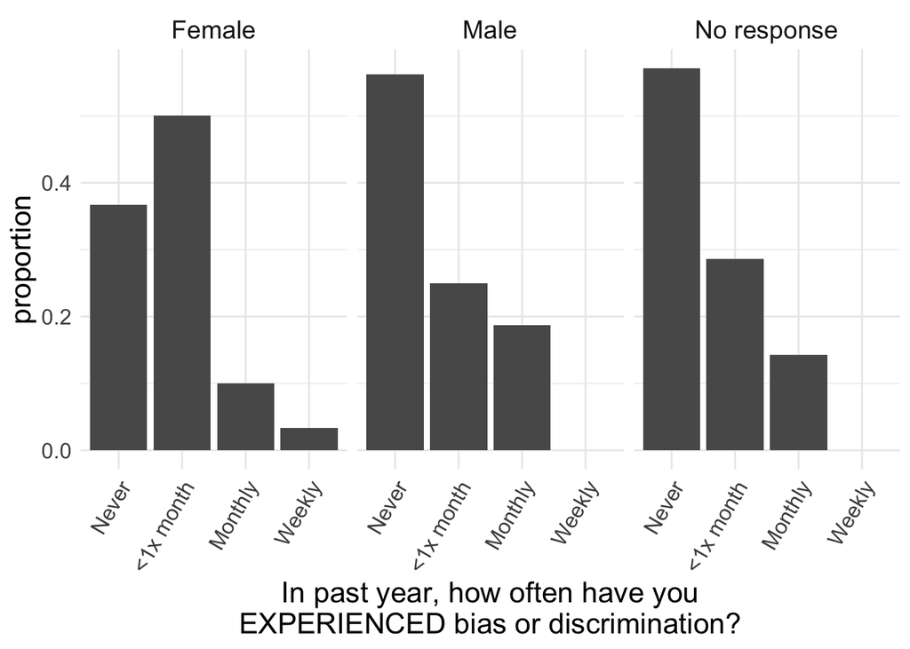

```r
count_bias_exp_gender <-
  d0 %>%
  count(gender_text, bias_exp) %>%
  group_by(gender_text) %>%
  mutate(
    proportion = n / sum(n)
  ) %>%
  arrange(gender_text, desc(n))

count_bias_exp_gender %>%
  mutate(
    bias_exp = factor(
      bias_exp,
      levels = c(
        "Never",
        "Less than once a month",
        "Every month",
        "Every week",
        "Every day"
      ),
      labels = c(
        "Never",
        "<1x month",
        "Monthly",
        "Weekly",
        "Daily"
      )
    )
  ) %>%
  ggplot(aes(bias_exp, proportion)) +
  geom_col() +
  hist_facet_theme +
  labs(
    x = "In past year, how often have you\nEXPERIENCED bias or discrimination?"
  ) +
  facet_grid(.~gender_text)
```

## Collective action

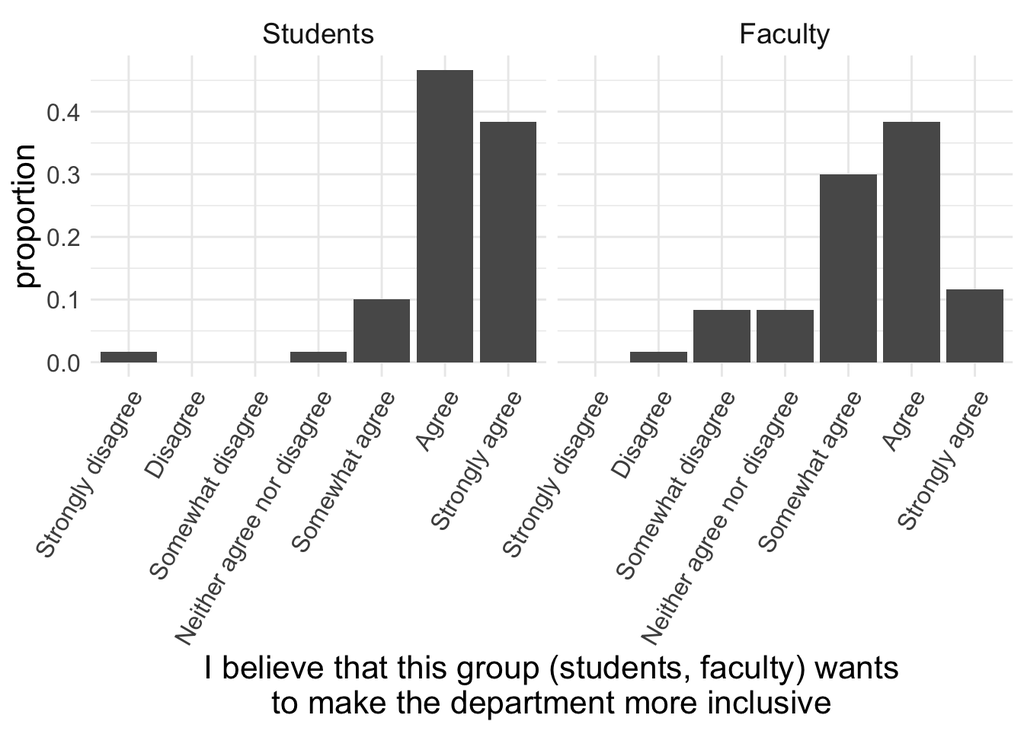

```r
d0_gather_inclus <-
  d0 %>%
  gather(Q, value, inclus_stud, inclus_fac)

count_inclus <-
  d0_gather_inclus %>%
  count(Q, value) %>%
  group_by(Q) %>%
  mutate(
    proportion = n / sum(n)
  ) %>%
  arrange(Q, desc(n)) %>%
  ungroup()

count_inclus %>%
  filter(!is.na(value)) %>%
  mutate(
    value = factor(
      value,
      levels = c(
        "Strongly disagree",
        "Disagree",
        "Somewhat disagree",
        "Neither agree nor disagree",
        "Somewhat agree",
        "Agree",
        "Strongly agree"
      )
    ),
    Q = factor(
      Q,
      levels = c(
        "inclus_stud",
        "inclus_fac"
      ),
      labels = c(
        "Students",
        "Faculty"
      )
    )
  ) %>%
  ggplot(aes(value, proportion)) +
  geom_col() +
  hist_facet_theme +
  labs(
    x = "I believe that this group (students, faculty) wants\nto make the department more inclusive"
  ) +
  facet_grid(.~Q)
```

## Open-ended questions

```r
d0 %>%
  count(share)
```

```
## # A tibble: 3 x 2
##   share     n
##   <chr> <int>
## 1 No        4
## 2 Yes      29
## 3 <NA>     27
```

! Note that 4 participants do not want their free responses shared outside of this analysis. If sharing responses in another form, remove these responses.

### Experiences of belonging and belonging uncertainty

**In the past year, when was a time you felt like you belonged in the department? Please briefly describe the situation and what made you feel like you belong.**

```r
d0 %>%
  count(!is.na(belong_free))
```

```
## # A tibble: 2 x 2
##   `!is.na(belong_free)`     n
##   <lgl>                 <int>
## 1 FALSE                    40
## 2 TRUE                     20
```

```r
d0 %>%
  filter(!is.na(belong_free)) %>%
  select(belong_free)
```

```
## # A tibble: 20 x 1
##    belong_free
##    <chr>
##  1 Serving on the diversity committee has helped me feel like I belong. It's be…
##  2 Gave a talk that was generally well received
##  3 My advisor listened to my critiques of his feedback/mentoring style in a non…
##  4 When a faculty member who I don't work with (but have interacted with before…
##  5 It's hard to think of a specific instance. Most of the time I don't feel lik…
##  6 There was a big department potluck within the past year (I can't remember th…
##  7 When teammates acknowledged my contribution and at the same time told me exp…
##  8 When I asked an older student in my area for advice. I felt seen, valued, an…
##  9 We had a community dinner in the spring for students across the department, …
## 10 The first-year celebration where the chair 'awarded' wine to us. I felt like…
## 11 "Based on my identity and my experiences both here and elsewhere, I'm partic…
## 12 When I have people around me who care about me/ask how I'm doing.
## 13 When I dont feel I know the historic psych literature as someone who did not…
## 14 When the 2nd years hosted a surprise FYP party for us first years. That was …
## 15 I really enjoyed the dinner at Tony Norcia's house to welcome prospective gr…
## 16 When people thanked me for building community in the department.
## 17 Watching incredible women give job talks during colloquium.
## 18 When I have good meetings with professors - they show that they are invested…
## 19 Our lab has several gatherings a year, such as end of year parties or holida…
## 20 End of academic year grad student dinner. Was one of the few times all grad …
```

**In the past year, when was a time you felt like you didn’t belong in the department? Please briefly describe the situation and what made you feel like you didn’t belong.**

```r
d0 %>%
  count(!is.na(nobelong_free) & nobelong_free != "N/A")
```

```
## # A tibble: 2 x 2
##   `!is.na(nobelong_free) & nobelong_free != "N/A"`     n
##   <lgl>                                            <int>
## 1 FALSE                                               45
## 2 TRUE                                                15
```

```r
d0 %>%
  filter(!is.na(nobelong_free) & nobelong_free != "N/A") %>%
  select(nobelong_free)
```

```
## # A tibble: 15 x 1
##    nobelong_free
##    <chr>
##  1 I have been called out on my stats knowledge by a man despite being quite kn…
##  2 Classes can be pretty hostile and non-welcoming to people who don't have agg…
##  3 "One instance-I felt like I don't belong when the media outreach team sent a…
##  4 I attended a conference with some other folks in the department, and a few o…
##  5 When I felt that those above me in the lab hierarchy were acting in a condes…
##  6 During a challenging class outside my area, I sometimes questioned my intell…
##  7 "Usually it is when individuals are talking about other people when they are…
##  8 "When faculty don't send a reply to my email (meeting request) -- It really …
##  9 I think I just get experiences intermittently where I am sitting at my desk …
## 10 When professors asked students' opinions about what statistics classes and t…
## 11 When I learned of social events that I wasn't invited to. Once there was a p…
## 12 One situation that has come up multiple times is when receiving feedback on …
## 13 Conversations with my advisor often feel hostile and openly alienating.
## 14 As I am thinking through some of my goals for post-graduation and realizing …
## 15 When research findings weren't planning out. Even though I know that's just …
```

### Issues and actions

**In your opinion, what are the biggest issues in regards to climate and issues of diversity in the department? Please provide up to 3 concrete ideas/examples.**

```r
d0 %>%
  count(!is.na(issues) & issues != "N/A")
```

```
## # A tibble: 2 x 2
##   `!is.na(issues) & issues != "N/A"`     n
##   <lgl>                              <int>
## 1 FALSE                                 41
## 2 TRUE                                  19
```

```r
d0 %>%
  filter(!is.na(issues) & issues != "N/A") %>%
  select(issues)
```

```
## # A tibble: 19 x 1
##    issues
##    <chr>
##  1 "1) We are not doing a great job fostering belonging toward different gender…
##  2 (1) For women (and for men and women who want to show up for their partners …
##  3 I think that the diversity committee sometimes sabotages its own goals. For …
##  4 Like I mentioned before, the stark participants style and frequency gap betw…
##  5 "1. Lack of knowledge about others' experiences. I don't know the degree to …
##  6 Climate: It can be hard to measure how well one is doing at their job, which…
##  7 "'-People don't understand that their actions are discriminatory/hurtful/con…
##  8 "'- resources and logistical support for students from marginalized backgrou…
##  9 "1) I think we need a standardized admissions review process across areas, o…
## 10 "1. The stigma around mental health: I've had many people reveal to me that …
## 11 "'-Name of the building as Jordan Hall, after a eugenicist...\n-Need for stu…
## 12 I don't think there are any issues. In my opinion, the department does an in…
## 13 "I don't feel super well positioned to comment on this, but one thing I see …
## 14 "1) Almost all-white faculty, new hires have been white men, and all but one…
## 15 "1) One issue is social support and professional development for RCs. RCs, l…
## 16 "Interactions between students and advisors- I don't know how to solve this,…
## 17 "1. Gender inclusion in the neuro area, which also extends to the general cl…
## 18 "1. I feel that I connected with people in my cohort and area and found a st…
## 19 "Cost of living (funding relative to housing)\nUp-front expenses for incomin…
```

**In your opinion, what are the possible actions that can be taken to improve the climate and issues of diversity in the department? Please provide up to 3 concrete ideas/examples.**

```r
d0 %>%
  count(!is.na(actions) & actions != "N/A")
```

```
## # A tibble: 2 x 2
##   `!is.na(actions) & actions != "N/A"`     n
##   <lgl>                                <int>
## 1 FALSE                                   45
## 2 TRUE                                    15
```

```r
d0 %>%
  filter(!is.na(actions) & actions != "N/A") %>%
  select(actions)
```

```
## # A tibble: 15 x 1
##    actions
##    <chr>
##  1 Adopt policy that everyone includes pronouns in email signatures. Adopt a po…
##  2 (1) Look at and respond to data from this survey! (Thanks for putting this t…
##  3 "Faculty can do a waaaaay better job at facilitating more balanced discussio…
##  4 "1. More open and honest conversations between students about such issues. T…
##  5 I think there should be a system in place for anonymous, bi-directional feed…
##  6 Culturally competent and skillful training on micro-aggressions and how to s…
##  7 See above
##  8 "'-Rename Jordan Hall\n-Have purchasing cards students can use to charge the…
##  9 On the point I mention above, I think we need to make considered efforts in …
## 10 "1) Hire more faculty of color\n2) Hire a quantitative faculty and have regu…
## 11 "1) RC inclusion: standardize intellectual development and contribution expe…
## 12 "There should be a course on \"How to build a research lab\" class for incom…
## 13 Lab managers and RAs should have the opportunity to give an evaluation of th…
## 14 "1. Have the faculty lead by example. The faculty should hold each other acc…
## 15 "Discussing solutions to cost of living with students\nUp-front payments whe…
```

## Gender dynamics

```r
count_gender_haras <-
  d0 %>%
  count(gender_text, gender_haras) %>%
  group_by(gender_text) %>%
  mutate(
    proportion = n / sum(n)
  ) %>%
  arrange(gender_text, desc(n)) %>%
  ungroup()

count_gender_haras
```

```
## # A tibble: 12 x 4
##    gender_text gender_haras     n proportion
##    <chr>       <chr>        <int>      <dbl>
##  1 Female      A little        10     0.333
##  2 Female      Not at all      10     0.333
##  3 Female      Moderately       8     0.267
##  4 Female      Extremely        1     0.0333
##  5 Female      Very             1     0.0333
##  6 Male        Not at all      11     0.688
##  7 Male        A little         2     0.125
##  8 Male        Moderately       2     0.125
##  9 Male        Extremely        1     0.0625
## 10 No response <NA>            11     0.786
## 11 No response Not at all       2     0.143
## 12 No response A little         1     0.0714
```

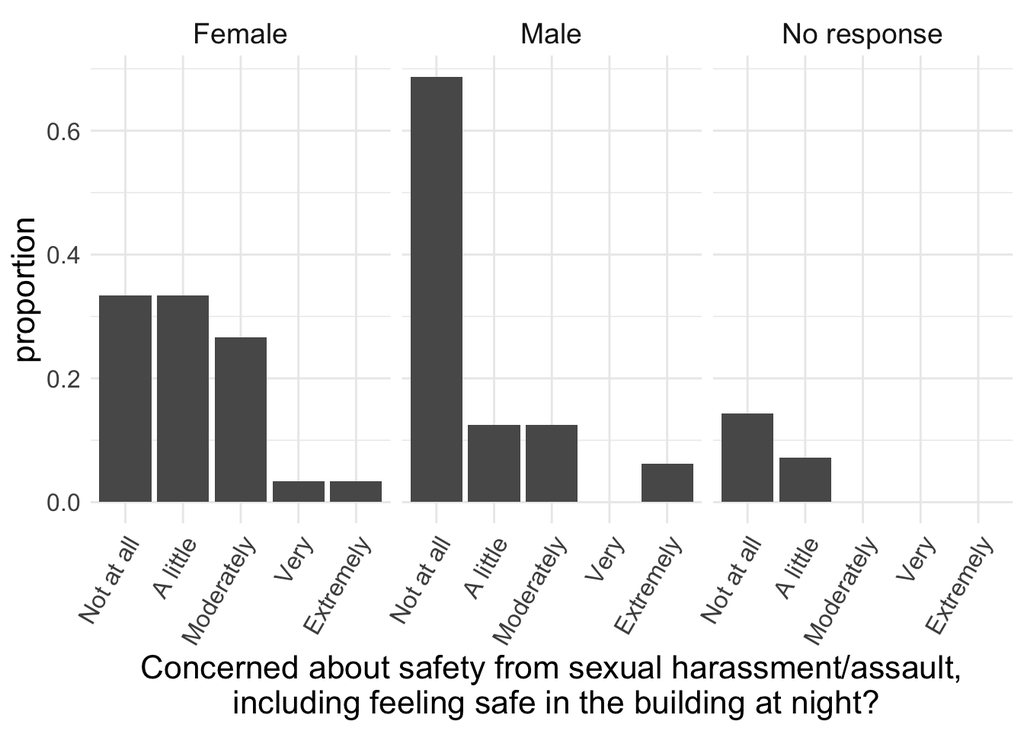

```r
count_gender_haras %>%
  filter(!is.na(gender_haras)) %>%
  mutate(
    gender_haras = factor(
      gender_haras,
      levels = c(
        "Not at all",
        "A little",
        "Moderately",
        "Very",
        "Extremely"
      )
    )
  ) %>%
  ggplot(aes(gender_haras, proportion)) +
  geom_col() +
  hist_facet_theme +
  labs(
    x = "Concerned about safety from sexual harassment/assault,\n including feeling safe in the building at night?"
  ) +
  facet_grid(.~gender_text)
```

```r
count_gender_inclus <-
  d0 %>%
  count(gender_text, gender_inclus) %>%
  group_by(gender_text) %>%
  mutate(
    proportion = n / sum(n)
  ) %>%
  arrange(gender_text, desc(n)) %>%
  ungroup()

count_gender_inclus
```

```
## # A tibble: 14 x 4
##    gender_text gender_inclus     n proportion
##    <chr>       <chr>         <int>      <dbl>
##  1 Female      Very             13     0.433
##  2 Female      Moderately        7     0.233
##  3 Female      Extremely         4     0.133
##  4 Female      A little          3     0.1
##  5 Female      Not at all        3     0.1
##  6 Male        Moderately        5     0.312
##  7 Male        Not at all        4     0.25
##  8 Male        A little          3     0.188
##  9 Male        Extremely         2     0.125
## 10 Male        Very              2     0.125
## 11 No response <NA>             11     0.786
## 12 No response A little          1     0.0714
## 13 No response Moderately        1     0.0714
## 14 No response Very              1     0.0714
```

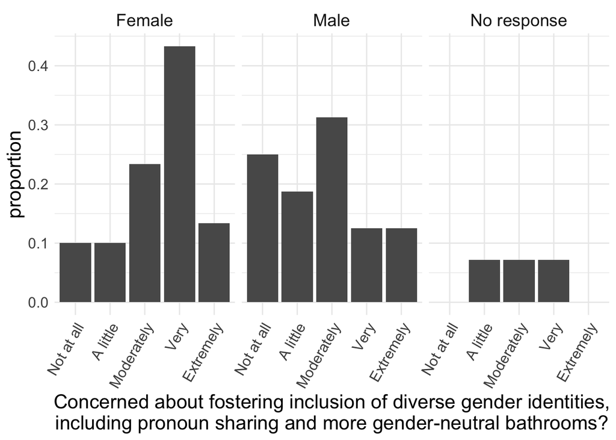

```r
count_gender_inclus %>%
  filter(!is.na(gender_inclus)) %>%
  mutate(
    gender_inclus = factor(
      gender_inclus,
      levels = c(
        "Not at all",
        "A little",
        "Moderately",
        "Very",
        "Extremely"
      )
    )
  ) %>%
  ggplot(aes(gender_inclus, proportion)) +
  geom_col() +
  hist_facet_theme +
  labs(
    x = "Concerned about fostering inclusion of diverse gender identities,\nincluding pronoun sharing and more gender-neutral bathrooms?"
  ) +
  facet_grid(.~gender_text)
```

```r
count_gender_speak <-
  d0 %>%
  count(gender_text, gender_speak) %>%
  group_by(gender_text) %>%
  mutate(
    proportion = n / sum(n)
  ) %>%
  arrange(gender_text, desc(n)) %>%
  ungroup()

count_gender_speak
```

```
## # A tibble: 14 x 4
##    gender_text gender_speak     n proportion
##    <chr>       <chr>        <int>      <dbl>
##  1 Female      Moderately       8     0.267
##  2 Female      Very             8     0.267
##  3 Female      A little         7     0.233
##  4 Female      Extremely        6     0.2
##  5 Female      Not at all       1     0.0333
##  6 Male        Very             4     0.25
##  7 Male        A little         3     0.188
##  8 Male        Extremely        3     0.188
##  9 Male        Moderately       3     0.188
## 10 Male        Not at all       3     0.188
## 11 No response <NA>            11     0.786
## 12 No response Extremely        1     0.0714
## 13 No response Moderately       1     0.0714
## 14 No response Very             1     0.0714
```

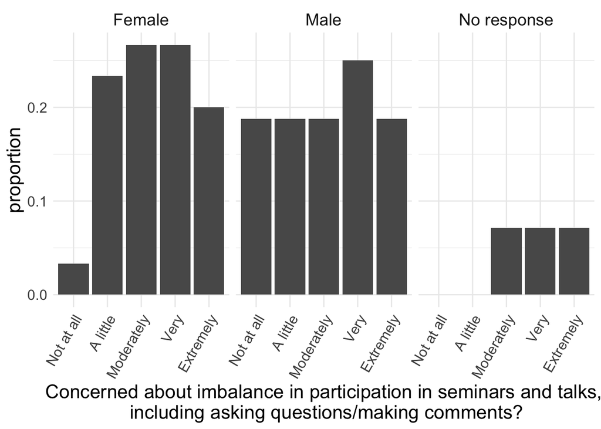

```r
count_gender_speak %>%
  filter(!is.na(gender_speak)) %>%
  mutate(
    gender_speak = factor(
      gender_speak,
      levels = c(
        "Not at all",
        "A little",
        "Moderately",
        "Very",
        "Extremely"
      )
    )
  ) %>%
  ggplot(aes(gender_speak, proportion)) +
  geom_col() +
  hist_facet_theme +
  labs(
    x = "Concerned about imbalance in participation in seminars and talks,\n including asking questions/making comments?"
  ) +
  facet_grid(.~gender_text)
```

```r
count_gender_fac <-
  d0 %>%
  count(gender_text, gender_fac) %>%
  group_by(gender_fac) %>%
  mutate(
    proportion = n / sum(n)
  ) %>%
  arrange(gender_fac, desc(n)) %>%
  ungroup()

count_gender_fac
```

```
## # A tibble: 14 x 4
##    gender_text gender_fac     n proportion
##    <chr>       <chr>      <int>      <dbl>
##  1 Female      A little       6     0.6
##  2 Male        A little       4     0.4
##  3 Female      Extremely      4     0.571
##  4 Male        Extremely      3     0.429
##  5 Female      Moderately     9     0.6
##  6 Male        Moderately     5     0.333
##  7 No response Moderately     1     0.0667
##  8 Female      Not at all     2     0.4
##  9 Male        Not at all     2     0.4
## 10 No response Not at all     1     0.2
## 11 Female      Very           9     0.75
## 12 Male        Very           2     0.167
## 13 No response Very           1     0.0833
## 14 No response <NA>          11     1
```

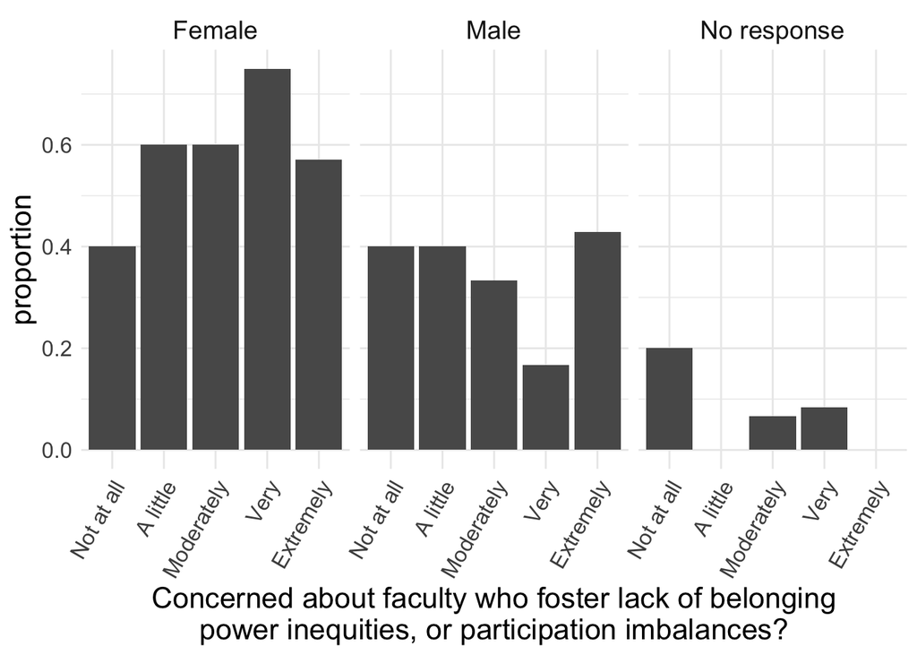

```r
count_gender_fac %>%
  filter(!is.na(gender_fac)) %>%
  mutate(
    gender_fac = factor(
      gender_fac,
      levels = c(
        "Not at all",
        "A little",
        "Moderately",
        "Very",
        "Extremely"
      )
    )
  ) %>%
  ggplot(aes(gender_fac, proportion)) +
  geom_col() +
  hist_facet_theme +
  labs(
    x = "Concerned about faculty who foster lack of belonging\npower inequities, or participation imbalances?"
  ) +
  facet_grid(.~gender_text)
```

## Participation in the Diversity Committee

```r
d0 %>%
  count(paths_volunt) %>%
  mutate(
    proportion = n / sum(n)
  )
```

```
## # A tibble: 3 x 3
##   paths_volunt     n proportion
##   <chr>        <int>      <dbl>
## 1 No              28      0.467
## 2 Yes             20      0.333
## 3 <NA>            12      0.2
```

```r
d0 %>%
  filter(dc_served == "No") %>%
  count(dc_interest) %>%
  mutate(
    proportion = n / sum(n)
  )
```

```
## # A tibble: 3 x 3
##   dc_interest      n proportion
##   <chr>        <int>      <dbl>
## 1 Probably not    24     0.585
## 2 Yes             15     0.366
## 3 <NA>             2     0.0488
```

```r
d0 %>%
  filter(dc_interest != "Yes") %>%
  select(dc_no_why) %>%
  arrange(dc_no_why)
```

```
## # A tibble: 24 x 1
##    dc_no_why
##    <chr>
##  1 Based on my identity, I do not think I should be on the Diversity Committee
##  2 Based on my identity, I do not think I should be on the Diversity Committee,…
##  3 I am already on one or more committees
##  4 I am already on one or more committees,I am too busy to serve on committees
##  5 I am already on one or more committees,Other
##  6 I am already on one or more committees,Service on committees is not valued b…
##  7 I am not interested in the mission and activities of the Diversity Committee
##  8 I am too busy to serve on committees
##  9 I am too busy to serve on committees
## 10 I am too busy to serve on committees
## # … with 14 more rows
```